# Doc texto

Moises

9/2/2020

# Encabezado 1

## Encabezado 2

### Encabezado 3

#### Encabezado 4

##### Encabezado 5

###### Encabezado 6

texto llano

formato en r = `R`

En latex =

NOTA: Para que haya un nuevo parrafo debe haber 2 saltos de linea

Para colocar cursiva = *Cursiva*

Para colocar negrita = **negrita**

Para colocar exponentes o superindices = al_cuadrado<sup>2</sup>

Para tachar una pablara = Math sucks

Para poner un link = [udemy](https://www.udemy.com/)

Para destacar algun ejemplo = –Por ejemplo

Para agregar un guion = —Este es un dialogo

Esto indica la ausencia de un fragmento = …

Para las formulas en linea = $\pi\cdot r^2$

Para una linea divisora =

Para hacer una cita de bloque = > Cita de bloque

Para crear listas desordenadas utiliza * asteriscos, - guiones, o + símbolo de suma = - Elemento de lista 1

- Elemento de lista 2
- Elemento de lista 3
- Elemento de lista 4
- Elemento de lista 5
- Elemento de lista 6

Para generar listas anidadas dentro de otras, simplemente tendrás que añadir **cuatro espacios en blanco antes del siguiente *, - o +.

- Elemento de lista 1
- Elemento de lista 2
  - Elemento de lista 3
  - Elemento de lista 4
    - Elemento de lista 5
    - Elemento de lista 6

Para crear listas ordenadas debes utilizar la sintaxis de tipo: “número.” 1.. Al igual que ocurre con las listas desordenadas, también podrás anidarlas o combinarlas.

1. Elemento de lista 1
2. Elemento de lista 2
   - Elemento de lista 3
   - Elemento de lista 4
3. Elemento de lista 5
4. Elemento de lista 6

Para crear una tabla (Las lineas deben estar alineadas) =

| Alumno | Nota |
| --- | --- |
| Moises Diaz | 3.4 |
| Juan Perez | 7.4 |
| Domingo contrer | 1.4 |

Para una imagen =

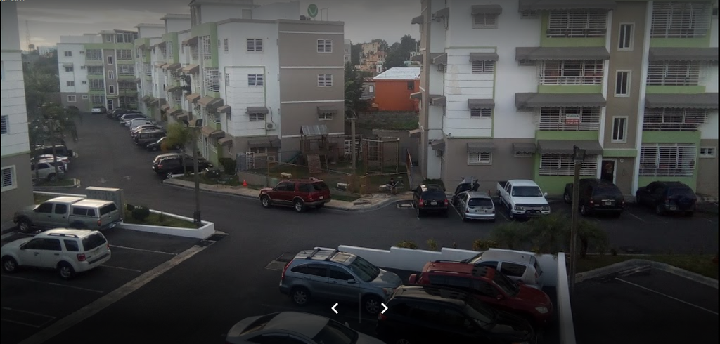